# **Multispecies Trait Data**

Fang-Kim-Lee-Reategui

# **Introduction**

This is our R Notebook, showing the steps we took to complete Project2 for CS 329E. This notebook includes step-by-step instructions on how to reproduce our project. To obtain our data, we used esapubs.org, an online ecological archive containing data sets on analyses of life history, ecological, and geographic trait differences among species. In this project, we analyze the information on traits to look at patterns among orders and species.

# **R Configuration**

# **The Data**

```
       MSW05_Order             MSW05_Family        MSW05_Genus     MSW05_Species
 Rodentia    :2277   Muridae         : 730   Crocidura   : 172   australis:  15
 Chiroptera  :1116   Cricetidae      : 681   Myotis      : 103   thomasi  :  15
 Soricomorpha: 428   Vespertilionidae: 407   Rhinolophus :  77   macrotis :  14
 Primates    : 376   Soricidae       : 376   Sorex       :  77   major    :  14
 Carnivora   : 286   Sciuridae       : 278   Hipposideros:  67   grandis  :  11
 Artiodactyla: 240   Pteropodidae    : 186   Rattus      :  66   minor    :  11
 (Other)     : 693   (Other)         :2758   (Other)     :4854   (Other)  :5336
              MSW05_Binomial X1.1_ActivityCycle X5.1_AdultBodyMass_g
 Abditomys latidens  :   1   Min.   :-999.0     Min.   :     -999
 Abeomelomys sevia   :   1   1st Qu.:-999.0     1st Qu.:     -999
 Abrawayaomys ruschii:   1   Median :-999.0     Median :       23
 Abrocoma bennettii  :   1   Mean   :-692.4     Mean   :   115940
 Abrocoma boliviensis:   1   3rd Qu.:   1.0     3rd Qu.:      282
 Abrocoma budini     :   1   Max.   :   3.0     Max.   :154321304
 (Other)             :5410
 X8.1_AdultForearmLen_mm X13.1_AdultHeadBodyLen_mm X2.1_AgeatEyeOpening_d
 Min.   :-999.0          Min.   : -999.0           Min.   :-999.0
 1st Qu.:-999.0          1st Qu.: -999.0           1st Qu.:-999.0
 Median :-999.0          Median : -999.0           Median :-999.0
 Mean   :-823.3          Mean   : -441.4           Mean   :-909.9
 3rd Qu.:-999.0          3rd Qu.:  131.0           3rd Qu.:-999.0
 Max.   : 246.0          Max.   :30480.0           Max.   : 153.5

 X3.1_AgeatFirstBirth_d X18.1_BasalMetRate_mLO2hr X5.2_BasalMetRateMass_g
 Min.   :-999.0         Min.   :  -999.0          Min.   :  -999.0
 1st Qu.:-999.0         1st Qu.:  -999.0          1st Qu.:  -999.0
 Median :-999.0         Median :  -999.0          Median :  -999.0
 Mean   :-848.9         Mean   :  -694.5          Mean   :   -42.3
 3rd Qu.:-999.0         3rd Qu.:  -999.0          3rd Qu.:  -999.0
 Max.   :5456.8         Max.   :113712.0          Max.   :407000.0

 X6.1_DietBreadth X7.1_DispersalAge_d X9.1_GestationLen_d X12.1_HabitatBreadth
 Min.   :-999.0   Min.   :-999.0      Min.   :-999.00     Min.   :-999.0
 1st Qu.:-999.0   1st Qu.:-999.0      1st Qu.:-999.00     1st Qu.:-999.0
 Median :-999.0   Median :-999.0      Median :-999.00     Median :   1.0
 Mean   :-599.4   Mean   :-961.6      Mean   :-719.85     Mean   :-495.9
 3rd Qu.:   2.0   3rd Qu.:-999.0      3rd Qu.:  12.06     3rd Qu.:   1.0
 Max.   :   8.0   Max.   :5249.0      Max.   : 660.00     Max.   :   4.0

```

[output cut: 72 more lines]

```
 X27.2_HuPopDen_Mean_n.km2 X27.3_HuPopDen_5p_n.km2 X27.4_HuPopDen_Change
 Min.   :-999.00           Min.   :-999.000        Min.   :-999.00
 1st Qu.:   6.00           1st Qu.:   0.000        1st Qu.:   0.03
 Median :  28.85           Median :   2.000        Median :   0.09
 Mean   : -69.94           Mean   :-122.374        Mean   :-145.82
 3rd Qu.:  75.60           3rd Qu.:   8.125        3rd Qu.:   0.12
 Max.   :2060.50           Max.   :1119.000        Max.   :   1.00

 X28.1_Precip_Mean_mm X28.2_Temp_Mean_01degC X30.1_AET_Mean_mm X30.2_PET_Mean_mm
 Min.   :-999.00      Min.   :-999.000       Min.   :-999.0    Min.   :-999.0
 1st Qu.:  29.83      1st Qu.:  68.150       1st Qu.: 269.3    1st Qu.: 639.6
 Median :  91.06      Median : 199.655       Median : 843.7    Median :1379.1
 Mean   : -61.84      Mean   :  -6.575       Mean   : 580.2    Mean   : 885.4
 3rd Qu.: 154.61      3rd Qu.: 239.215       3rd Qu.:1276.7    3rd Qu.:1577.0
 Max.   : 461.00      Max.   : 350.000       Max.   :1858.6    Max.   :2107.0
```

|  | MSW05_Order | MSW05_Family | MSW05_Genus | MSW05_Species | MSW05_Binomial | X1.1_ActivityCycle | X5.1_AdultBodyMass_g | X8.1_AdultForearmLen_mm | X13.1_AdultHeadBodyLen_mm | X2.1_AgeatEyeOpening_d | X3.1_AgeatFirstBirth_d | X18.1_BasalMetRate_mLO2hr | X5.2_BasalMetRateMass_g | X6.1_DietBreadth | X7.1_DispersalAge_d | X9.1_GestationLen_d | X12.1_HabitatBreadth | X22.1_HomeRange_km2 | X22.2_HomeRange_Indiv_km2 | X14.1_InterbirthInterval_d | X15.1_LitterSize | X16.1_LittersPerYear | X17.1_MaxLongevity_m | X5.3_NeonateBodyMass_g | X13.2_NeonateHeadBodyLen_mm | X21.1_PopulationDensity_n.km2 | X10.1_PopulationGrpSize | X23.1_SexualMaturityAge_d | X10.2_SocialGrpSize | … |
| --- | --- | --- | --- | --- | --- | --- | --- | --- | --- | --- | --- | --- | --- | --- | --- | --- | --- | --- | --- | --- | --- | --- | --- | --- | --- | --- | --- | --- | --- | --- |
| 1 | Artiodactyla | Camelidae | Camelus | dromedarius | Camelus dromedarius | 3 | 492714.47 | -999.00 | -999.00 | -999.00 | 1651.62 | 40293.00 | 407000.00 | 3 | -999.00 | 386.51 | 1 | 196.320000 | -999.000000 | 614.41 | 0.98 | 1.00 | 480.00 | 36751.19 | -999.00 | 0.98 | 11.00 | 1947.94 | 10.00 | … |
| 2 | Carnivora | Canidae | Canis | adustus | Canis adustus | 1 | 10392.49 | -999.00 | 745.32 | -999.00 | -999.00 | -999.00 | -999.00 | 6 | 329.99 | 65.00 | 1 | 1.010000 | 1.010000 | -999.00 | 4.50 | -999.00 | 137.00 | -999.00 | -999.00 | 0.74 | -999.00 | 249.88 | -999.00 | … |
| 3 | Carnivora | Canidae | Canis | aureus | Canis aureus | 2 | 9658.70 | -999.00 | 827.53 | 7.50 | -999.00 | -999.00 | -999.00 | 6 | -999.00 | 61.24 | 1 | 2.950000 | 3.130000 | 365.00 | 3.74 | -999.00 | 192.00 | 211.82 | -999.00 | 0.22 | -999.00 | 371.23 | -999.00 | … |
| 4 | Carnivora | Canidae | Canis | latrans | Canis latrans | 2 | 11989.10 | -999.00 | 872.39 | 11.94 | 365.00 | 3699.00 | 10450.00 | 1 | 255.00 | 61.74 | 1 | 18.880000 | 19.910000 | 365.00 | 5.72 | -999.00 | 262.00 | 200.01 | -999.00 | 0.25 | -999.00 | 372.90 | -999.00 | … |
| 5 | Carnivora | Canidae | Canis | lupus | Canis lupus | 2 | 31756.51 | -999.00 | 1055.00 | 14.01 | 547.50 | 11254.20 | 33100.00 | 1 | 180.00 | 63.50 | 1 | 159.860000 | 43.130000 | 365.00 | 4.98 | 2.00 | 354.00 | 412.31 | -999.00 | 0.01 | -999.00 | 679.37 | -999.00 | … |
| 6 | Artiodactyla | Bovidae | Bos | frontalis | Bos frontalis | 2 | 800143.05 | -999.00 | 2700.00 | -999.00 | -999.00 | -999.00 | -999.00 | 3 | -999.00 | 273.75 | -999 | -999.000000 | -999.000000 | 403.02 | 1.22 | 1.00 | 314.40 | 22977.05 | -999.00 | 0.54 | -999.00 | 610.97 | 40.00 | … |
| 7 | Artiodactyla | Bovidae | Bos | grunniens | Bos grunniens | -999 | 500000.00 | -999.00 | -999.00 | -999.00 | -999.00 | -999.00 | -999.00 | 2 | -999.00 | 273.75 | -999 | -999.000000 | -999.000000 | -999.00 | 1.00 | 1.00 | 267.00 | -999.00 | -999.00 | -999.00 | -999.00 | 755.15 | 110.00 | … |
| 8 | Artiodactyla | Bovidae | Bos | javanicus | Bos javanicus | 2 | 635974.34 | -999.00 | 2075.00 | -999.00 | 912.50 | -999.00 | -999.00 | 2 | -999.00 | 296.78 | 1 | -999.000000 | -999.000000 | -999.00 | 1.22 | 1.00 | 318.96 | -999.00 | -999.00 | 0.75 | 21.00 | 797.31 | 40.00 | … |
| 9 | Primates | Pitheciidae | Callicebus | cupreus | Callicebus cupreus | 3 | 1117.02 | -999.00 | 354.99 | -999.00 | -999.00 | -999.00 | -999.00 | -999 | -999.00 | 129.25 | 1 | -999.000000 | -999.000000 | 395.41 | 1.01 | -999.00 | -999.00 | 73.60 | -999.00 | 4.89 | -999.00 | -999.00 | 2.05 | … |
| 10 | Primates | Pitheciidae | Callicebus | discolor | Callicebus discolor | -999 | -999.00 | -999.00 | -999.00 | -999.00 | -999.00 | -999.00 | -999.00 | -999 | -999.00 | -999.00 | -999 | -999.000000 | -999.000000 | -999.00 | -999.00 | -999.00 | -999.00 | -999.00 | -999.00 | -999.00 | -999.00 | -999.00 | -999.00 | … |

[output cut: 990 more lines]

# **Visualizations**

**Adult Forearm Length vs. Adult Head Body Length:** A visualization comparing the correlation between forearm length of adult species (in mm) to head body lengths (in mm) across various orders.

**Adult Body Head Size:** A visualization showcasing the adult body head sizes (in mm) of various orders.

**Longevity of Orders:** A visualization showcasing the length of lifespans (in months) for various orders.

**Sexual Maturity vs. Max Longevity:** A comparison between the age of sexual maturity (in days) of various orders to their maximum longevity (in months).

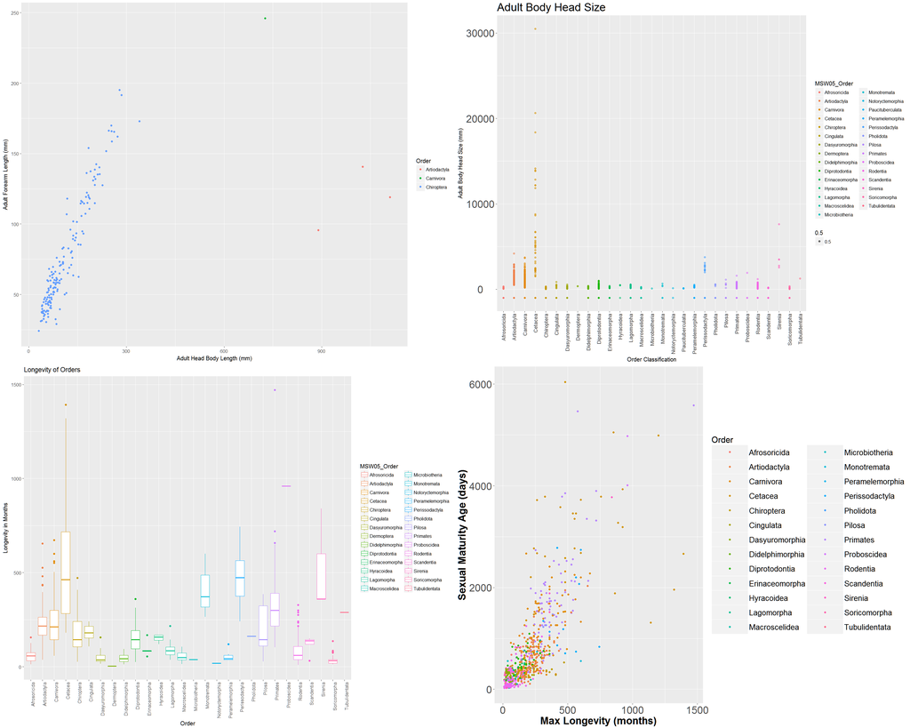